# Visualisasi Data dengan `ggplot2`

### 4.1.2 Customized aesthetics with `scale_` functions

We’ve learned to use `scales` functions to update breaks and labels. It is also useful for updating aesthetics, for example to customize color gradients, set size bins, and more.

Again, it is very important to know **what aesthetic you are trying to update.**

For example, is it a **fill** aesthetic you’re hoping to customize? Then you might use `scale_fill_*()`. But if it is a **color** aesthetic, you’d use `scale_color_*()` functions. If it is the transparency, then `scale_alpha_*()`. If it is the shape, then `scale_shape_*()`. So make sure you know *which aesthetic you are hoping to change with scales!*

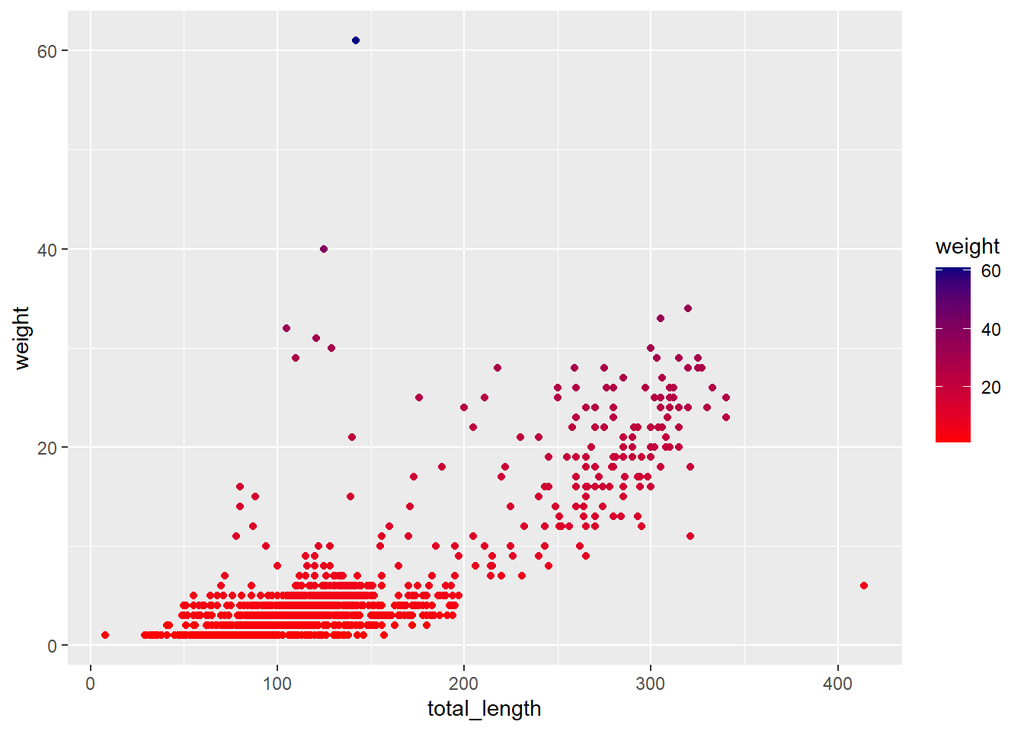

```r
ggplot(data = lizards, aes(x = total_length, y = weight)) +
  geom_point(aes(color = weight)) +
  scale_color_gradient(low = "red", high = "navy")
```

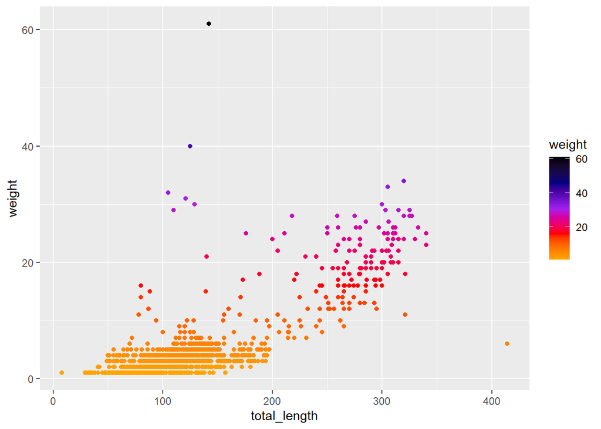

```r
# Or have more than 2 colors in your gradient:
ggplot(data = lizards, aes(x = total_length, y = weight)) +
  geom_point(aes(color = weight)) +
  scale_color_gradientn(colors = c("orange", "red", "purple", "navy", "black"))
```

```r
# Or use a palette from paletteer!
# Check out options: https://emilhvitfeldt.github.io/paletteer/

# ggplot(data = lizards, aes(x = total_length, y = weight)) +
#   geom_point(aes(color = weight)) +
#   scale_color_paletteer_c("scico::oslo")

# See more continuous palettes with View(palettes_c_names)
```

There are also great options for *binning* colors for a continuous variable, including with the `scale_*_steps()` functions (see more: https://ggplot2.tidyverse.org/reference/scale_steps.html). For example, maybe in the graph above we want binned (instead of continuous gradient) color values:

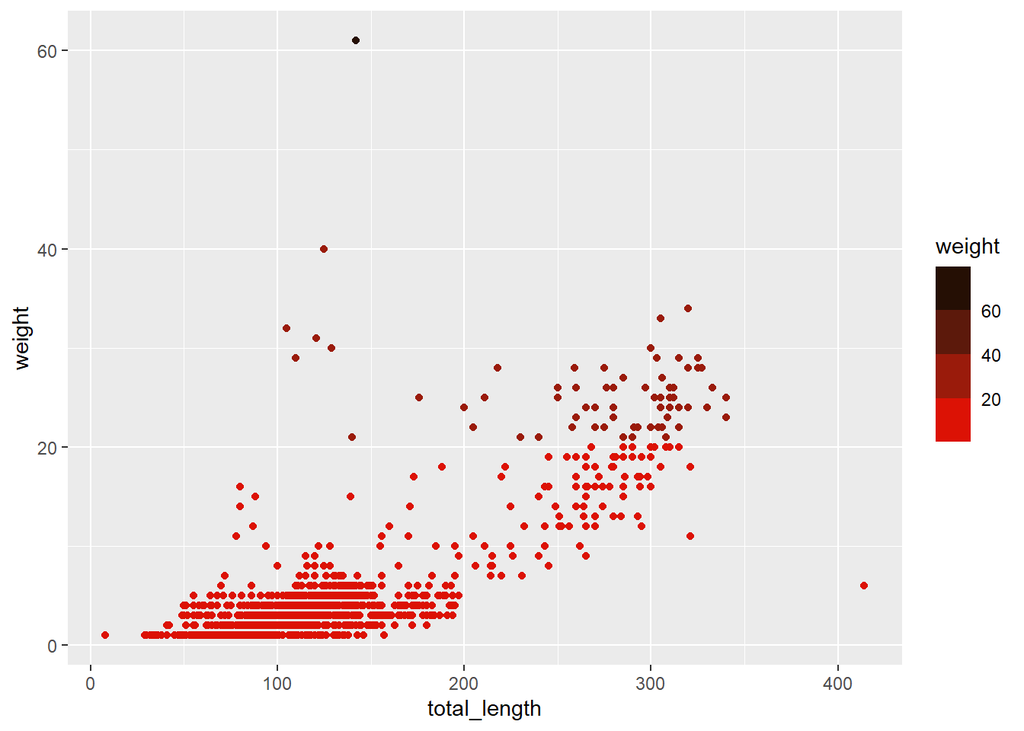

```r
ggplot(data = lizards, aes(x = total_length, y = weight)) +
  geom_point(aes(color = weight)) +
  scale_color_steps(low = "red", high = "black")
```

```r
# Notice the binned legend - within bins all points are the same value.
# Use n.breaks =  or breaks = c() to manually set the break number or value.
```

You can create a divergent binned scheme with `scale_*_steps2()`:

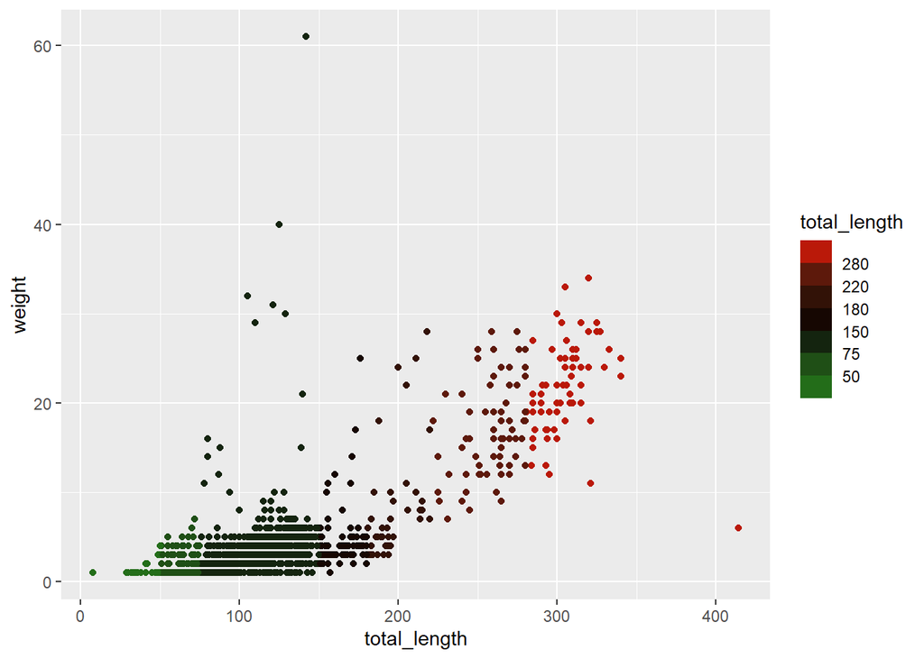

```r
ggplot(data = lizards, aes(x = total_length, y = weight)) +
  geom_point(aes(color = total_length)) +
  scale_color_steps2(low = "green",
                     mid = "black",
                     high = "red",
                     midpoint = 150,
                     breaks = c(50, 75, 150, 180, 220, 280))
```

Or, to make your own bins, try `scale_*_stepsn()`:

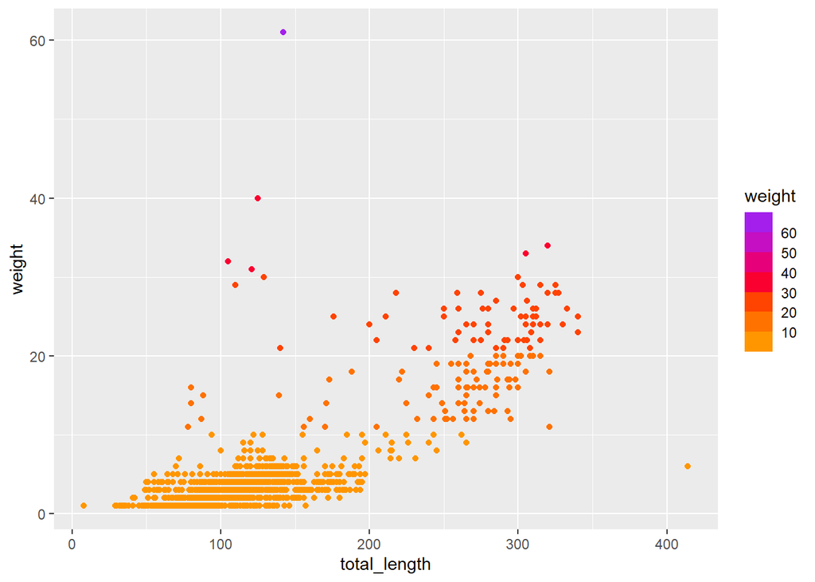

```r
ggplot(data = lizards, aes(x = total_length, y = weight)) +
  geom_point(aes(color = weight)) +
  scale_color_stepsn(colors = c("orange","red","purple"),
                     breaks = seq(from = 10, to = 60, by = 10))
```

What if we have a discrete variable? Let’s make a boxplot of lizard lengths by species, then customize the fill color with a palette in `paletteer`:

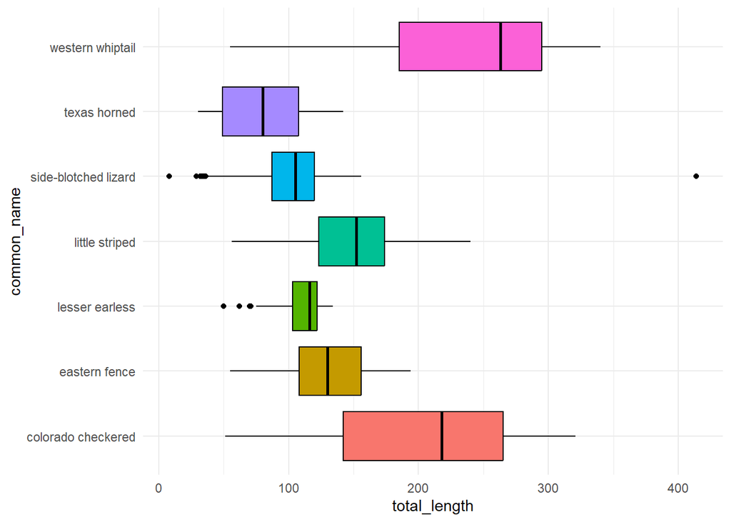

```r
ggplot(data = lizards, aes(x = common_name, y = total_length)) +
  geom_boxplot(aes(fill = common_name), color = "black", show.legend = FALSE) +
  theme_minimal() +
  coord_flip()
```

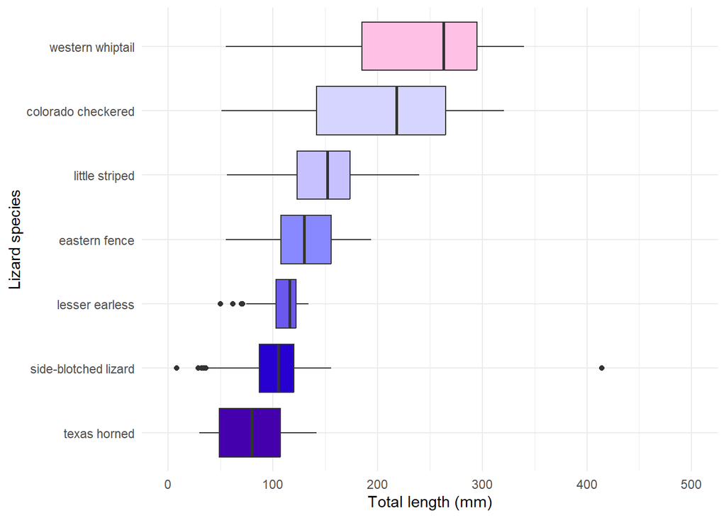

```r
# But **order matters**, so let's make an ordered version:

lizards_mean <- lizards %>%
  mutate(common_name = fct_reorder(common_name, total_length, .fun = median))

# Then make a graph (use View(palettes_d_names) to see other discrete palettes in {paletteer})

ggplot(data = lizards_mean, aes(y = common_name, x = total_length)) +
  geom_boxplot(aes(fill = common_name), show.legend = FALSE) +
  scale_x_continuous(limits = c(0, 500)) +
  scale_fill_paletteer_d(palette = "ggsci::default_gsea") +
  labs(y = "Lizard species",
       x = "Total length (mm)") +
  theme_minimal()
```

Cool let’s try another one: Find counts of lizard by species, reorder factor levels by count, update aesthetic by color (removing redundant legend), customize color using something from `paletteer`:

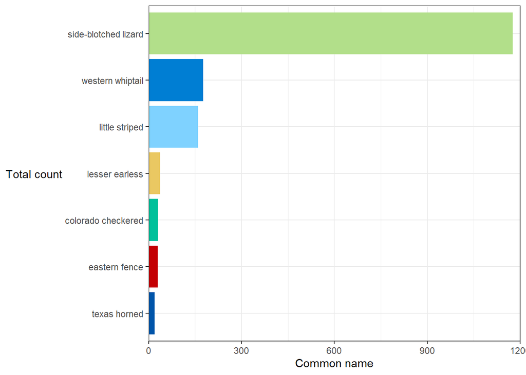

```r
lizard_n <- lizards %>%
  count(common_name) %>%
  mutate(common_name = fct_reorder(common_name, n))

ggplot(data = lizard_n, aes(y = common_name, x = n)) +
  geom_col(aes(fill = common_name), show.legend = FALSE) +
  scale_fill_paletteer_d("tidyquant::tq_dark") +
  scale_x_continuous(expand = c(0,0), limits = c(0, 1200)) +
  theme_bw() +
  labs(x = "Common name",
       y = "Total count") +
  theme(axis.title.y = element_text(angle = 0, vjust = 0.5))
```

## 4.2 In the weeds of themes (gridlines, panel colors)

Ask yourself: do you need those gridlines? Only if your audience needs to know whether values are above or below meaningful values - which can be useful, but oftentimes gridlines are really overused and make an entire plot feel more cluttered.

We can update gridline frequency by changing breaks, but we may want to customize them in other ways, too.

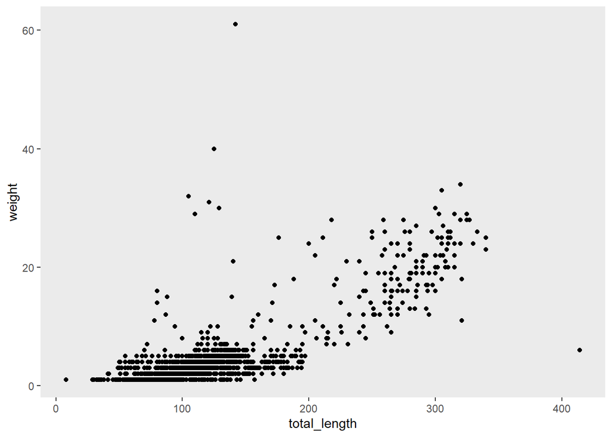

```r
p <- ggplot(data = lizards, aes(x = total_length, y = weight)) +
  geom_point()

p +
  theme(panel.grid = element_blank()) # removes all gridlines (major & minor)
```

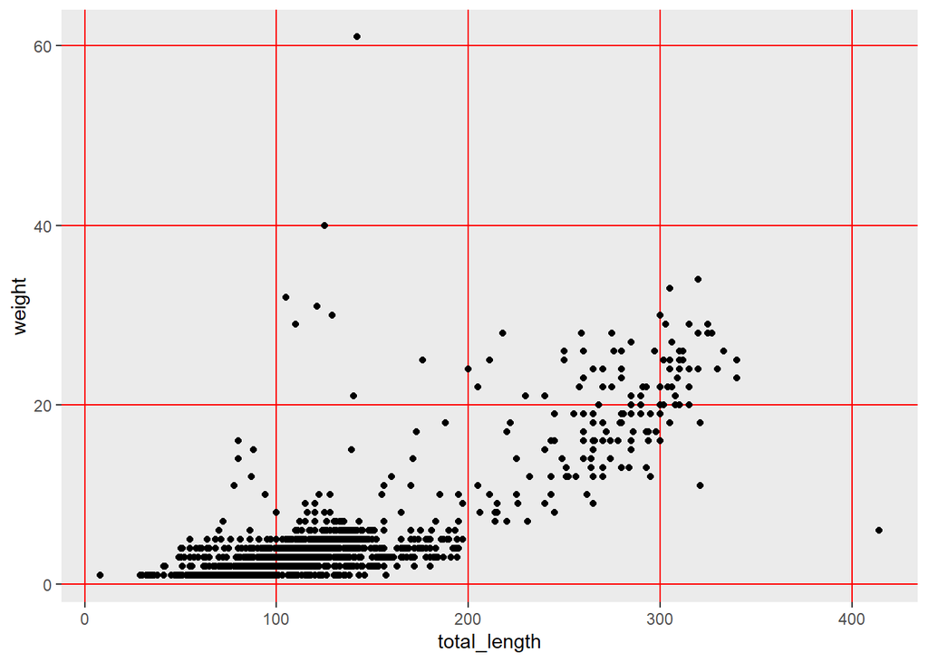

```r
p +
  theme(panel.grid.minor = element_blank(),
        panel.grid.major = element_line(color = "red"))
```

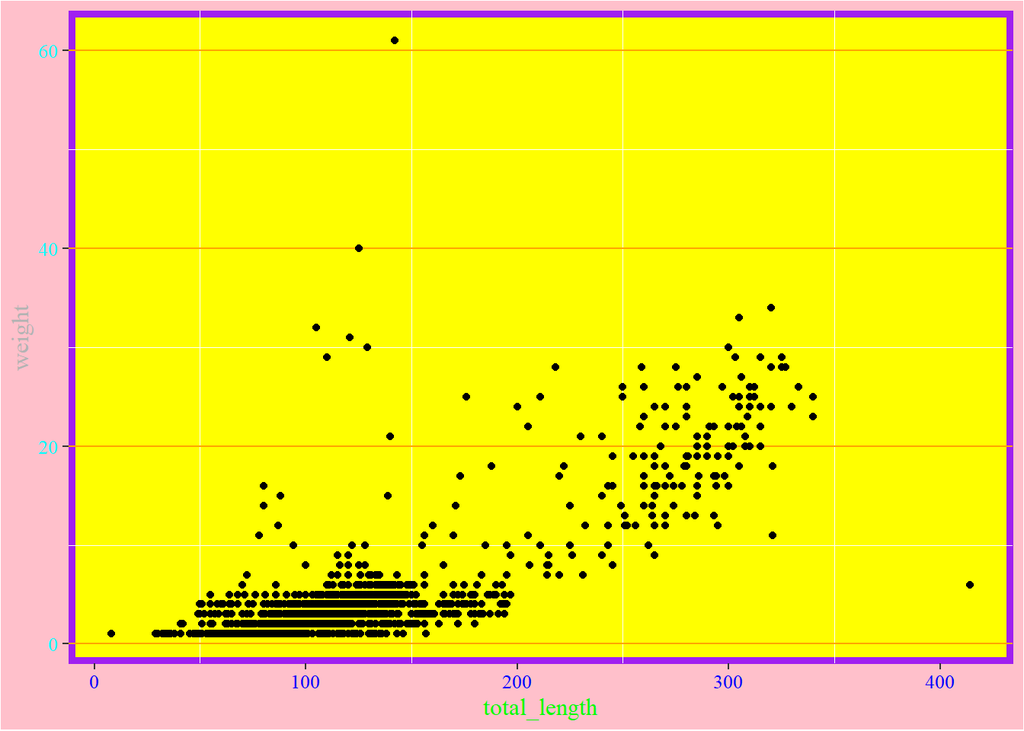

```r
# Now let's just go bananas with some theme stuff:

p +
  theme(panel.background = element_rect(color = "purple", size = 3, fill = "yellow"),
        panel.grid.major.y = element_line(color = "orange"),
        panel.grid.major.x = element_blank(),
        axis.text.x = element_text(color = "blue"),
        axis.text.y = element_text(color = "cyan"),
        axis.title.x = element_text(color = "green"),
        axis.title.y = element_text(color = "gray70"),
        text = element_text(size = 12, family="serif"),
        plot.background = element_rect(fill = "pink"))
```

```r
# Watch Kara Woo's talk from RStudio Conference 2021!
```